# Vignette Title

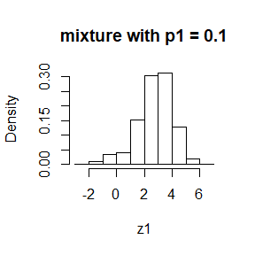

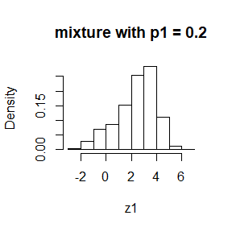

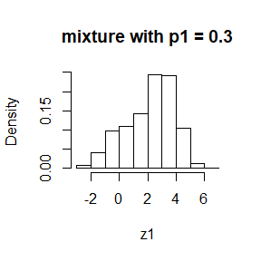

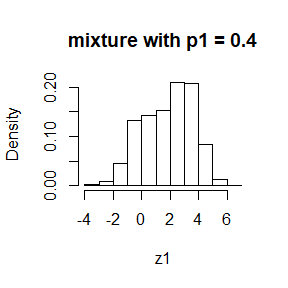

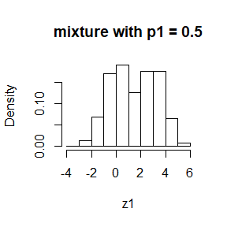

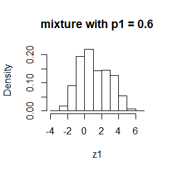

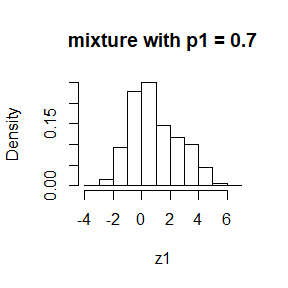

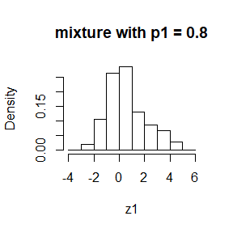

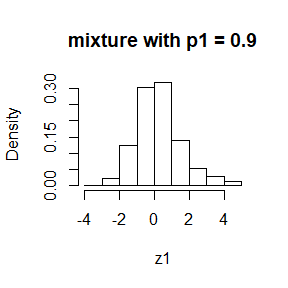

```r
#par(mfrow = c(3,3))
for (i in 1:9) {
u <- runif(n)
p1 <- 0.1*i
k <- as.integer(u < p1)
z1 <- k*x1 + (1 - k)*x2
hist(z1, prob = T, main = paste("mixture","with","p1","=",p1))
}
```

exercise 3.18

```r
n = 4
Sigma <- matrix(c(1, .9, .9, 1), nrow = 2, ncol = 2)
set.seed(1000)
rwish.bart <- # a function to generate samples from a Wishart distribution Wd(n,Sigma) based on Bartlett's decomposition
  function(n, Sigma){ #n>d+1>=1
    d = sqrt(length(Sigma))
    T <- matrix(rep(0,d^2), nrow = d, ncol = d)
    for (i in 1:d) {
      for (j in 1:d) {
        if (i>j){T[i,j] = rnorm(1)}
        if (i==j){T[i,j] = rchisq(1, n-i+1)}
      }
    }
    A <- T %*% t(T)
    L <- t(chol(Sigma))
    X <- L %*% A %*% t(L)
    X
  }
rwish.bart(n, Sigma)
```

```
##          [,1]     [,2]
## [1,] 4.029775 4.062549
## [2,] 4.062549 4.098733
```

Homework 2

exercise 5.1

Compute a Monte Carlo estimate of
$$\int_{0}^{\pi / 3} \sin t d t$$
and compare the estimate with the exact value of the integral.

```r
m <- 1e4
set.seed(1000)
x <- runif(m, min = 0, max = pi/3)
theta.hat <- mean(sin(x))*pi/3
print(c(theta.hat,-cos(pi/3)+cos(0)))#Compare the estimte and the true value
```

```
## [1] 0.4992055 0.5000000
```

exercise 5.10

Use Monte Carlo integration with antithetic variables to estimate
$$\int_{0}^{1} \frac{e^{-x}}{1+x^{2}} d x$$
and find the approximate reduction in variance as a percentage of the variance without variance reduction.

```r
MC <- function( R , antithetic = TRUE) { # Write a function to generate the estimate with antithetic variables or not
  u <- runif(R/2)
  if (!antithetic) v <- runif(R/2) else v <- 1 - u
  u <- c(u, v)
  theta <- mean(exp(-u)/(1+u^2))
  theta
}
m <- 1000
MC1 <- MC2 <- numeric(m)
set.seed(100)
for (i in 1:m) {
  MC1[i] <- MC(R = 1000, anti = FALSE)# the estimate without variance reduction
  MC2[i] <- MC(R = 1000)# the estimate with variance reduction
}
c(sd(MC1),sd(MC2),sd(MC2)/sd(MC1))
```

```
## [1] 0.007618082 0.001478508 0.194078734
```

exercise 5.15

Obtain the stratified importance sampling estimate in Example 5.13 and compare it with the result of Example 5.10.

```r
M <- 10000
k <- 5
r <- M/k # replicates per stratum
N <- 100 # number of times to repeat the estimation
T2 <- numeric(k)
estimate <- matrix(0, N, 2)
g <- function(x)exp(-x)/(1+x^2)
f <- function(x)exp(-x)/(1-exp(-1))
F <- function(x)-log(1-x*(1-exp(-1))) # the inverse function of the cdf of f(x)
set.seed(10)
for (i in 1:N)
{
  u <- runif(M)
  x <- F(u)
  estimate[i,1] <- mean(g(x)/f(x))
  for (j in 1:k )
  {
    u <- runif( M/k, F((j-1)/k),F(j/k))
    x<- F(u)
    T2[j] <- mean(g(x)/(f(x)))
  }
  estimate[i,2] <- mean(T2)
}
knitr::kable(rbind(apply(estimate,2,mean),apply(estimate,2,sd)), formate = "html",col.names = c("5.10","5.13"))
```

| 5.10 | 5.13 |
| --- | --- |
| 0.5248858 | 0.5492678 |
| 0.0010201 | 0.0002136 |

The standerd error of the stratified importance sampling estimate in Example 5.13 is only 20 percent of that result of Example 5.10.

Homework 3

exercise 6.5

Suppose a 95% symmetric t-interval is applied to estimate a mean, but the sample data are non-normal. Then the probability that the confidence interval covers the mean is not necessarily equal to 0.95. Use aMonte Carlo experiment to estimate the coverage probability of the t-interval for random samples of χ2(2) data with sample size n = 20. Compare your t-interval results with the simulation results in Example 6.4. (The t-interval should be more robust to departures from normality than the interval for variance.)

As we know while $X_i$ are normally distributed random variables, then
$$\overline{\boldsymbol{x}} \pm t_{\alpha / 2, n-1}\left(\frac{s}{\sqrt{n}}\right)$$
is the t-interval for th mean.

Note that the mean of χ2(n) is n and the variance is 2n.

```r
n <- 20
alpha <- .05
N <- 1000
TL1 <- TL2 <- UCL <-numeric(N)
set.seed(12345)
for (i in 1:N) {
  x <- rchisq(n, df = 2)
  y <- qt(1-alpha/2, df = n-1)*sqrt(var(x)/n)
  TL1[i] <- mean(x)-y# the lower confidence limit of t-interval
  TL2[i] <- mean(x)+y# the upper confidence limit of t-interval
  UCL[i] <- (n-1)*var(x)/qchisq(alpha, df = n-1)# the upper confidence limit of the variance
}
mean(TL1 < 2 & TL2 > 2)# the coverage probability of the t-interval
```

```
## [1] 0.918
```

```r
mean(UCL > 4)# the coverage probability of the one side confidence interval of the variance
```

```
## [1] 0.77
```

```r
rm(list = ls())
```

We find that the cverage probability of the t-interval shows better, so the t-interval could be more robust to departures from normality than the interval for variance.

exercise 6.6

Estimate the 0.025, 0.05, 0.95, and 0.975 quantiles of the skewness $\sqrt{b_1}$under normality by a Monte Carlo experiment. Compute the standard error of the estimates from (2.14) using the normal approximation for the density (with exact variance formula). Compare the estimated quantiles with the quantiles of the large sample approximation $\sqrt{b_{1}} \approx N(0,6 / n)$.

```r
n <- 100#the size of normal samples
m <- 100#the size of skewness samples
N <- 100#the number of simulations
qua <- c(0.025,0.05,0.95,0.975)#the vecter of quantiles
set.seed(1000)
sk <- function(x){# compute the sample skewness coeff
  xmean <- mean(x)
  m3 <- mean((x-xmean)^3)
  m2 <- mean((x-xmean)^2)
  m3/m2^1.5
}
q1 <- q2 <- q3 <- q4 <-numeric(N)# to storage the 0.025,0.05,0.95 and 0.975 quantiles of the skewness
skw <- numeric(m)# to storage the skewness of the samples
for (i in 1:N) {
  for (j in 1:m) {
    x <- rnorm(n)
    skw[j] <- sk(x)
  }
  q <- quantile(skw,qua,names = F)#find the quantiles
  q1[i] <- q[1]
  q2[i] <- q[2]
  q3[i] <- q[3]
  q4[i] <- q[4]
}
q.hat <- numeric(4)
q.hat[1] <- mean(q1)#0.025 quantile estimate
q.hat[2] <- mean(q2)#0.05 quantile estimate
q.hat[3] <- mean(q3)#0.95 quantile estimate
q.hat[4] <- mean(q4)#0.975 quantile estimate
q.hat#the estimates of such quantiles
```

```
## [1] -0.4453413 -0.3781042  0.3857467  0.4548685
```

```r
qua.var <- function(q, n){#the 2.14 formula
  xq <- qnorm(q, sd = sqrt(6*(n-2)/((n+1)*(n+3))))
  q*(1-q)/(n*dnorm(xq, sd = sqrt(6*(n-2)/((n+1)*(n+3))))^2)
}
q.sd <- numeric(4)# to storage the standard error
for (i in 1:4) {
  q.sd[i] <- sqrt(qua.var(qua[i], n))
}
q.sd# the standard error of the estimates from 2.14
```

```
## [1] 0.06350878 0.05023974 0.05023974 0.06350878
```

```r
q.large <- numeric(4)
for (i in 1:4) {
  q.large[i] <- qnorm(qua[i], sd = sqrt(6/n))
}
q.large# the estimates of quantiles with the large sample approximation
```

```
## [1] -0.4800912 -0.4029052  0.4029052  0.4800912
```